# *Objective:* Tag articles with disease-related keywords and concepts and organize into concept taxonomy

# *Method:* Use purpose-built biomedical entity-recognition model to extract disease names. Then, use frequenty pattern mining to organize taxonomy

A common problem I've referenced in these notebooks is the disparity between "standard english" and biomedical writing, meaning successful pre-trained models from the NLP literature will perform poorly when applied to biomedical text mining applications. This necessitates that I use a purpose-built biomedical Entity Recognition model to extract disease names and concepts from paper abstracts, and luckily, I found just such a model in AllenAI's `scispacy` package.

Using this model, I can extract important concepts from the literature and tag each article for easy filtering. Additionally, I used frequent pattern mining to identify correlated concepts in the tag-sets for each document. Using these corellations, I was able to construct a term taxonomy, which holds important advantages for intelligent filtering of papers by Constellation users (more on this later).

```python
import pandas as pd
import numpy as np
import spacy
import scispacy
from scispacy.abbreviation import AbbreviationDetector
import networkx as nx
import os
import seaborn
from itertools import permutations
seaborn.set(color_codes = True)
import json
import networkx as nx
data_dir = 'D:\datasets\covid'
```

```python
data = pd.read_csv(os.path.join(data_dir, 'analysis_v2', 'metadata_plus_analysis.csv')).set_index('index')
```

```python
nlp = spacy.load("en_ner_bc5cdr_md")
abbreviation_pipe = AbbreviationDetector(nlp)
nlp.add_pipe(abbreviation_pipe)
```

```python
def entity_tag(title):
    doc = nlp(title)
    tags = []
    for entity in doc.to_json()['ents']:
        if entity['label'] == 'DISEASE':
            entity_str = title[entity['start'] : entity['end']]
            found_abbrev = False
            for abbrev in doc._.abbreviations:
                if entity_str == abbrev.text:
                    tags.append(abbrev._.long_form.text)
                    found_abbrev = True
                    break
            if not found_abbrev:
                tags.append(entity_str)
    return list(set(tags))

tags = data.apply(lambda x : entity_tag(x.abstract), axis = 1)
```

```python
tags
```

```
index
3         [hypersensitivity, systemic lupus erythematosus]
5        [infectious diarrhea, hemolytic-uremic syndrom...
6        [synovitis, rheumatoid arthritis, inflammation...
7        [bronchitis, respiratory tract infections, res...
8        [fever, acute bronchitis, inflammation, cough,...
                               ...
44215    [Coronavirus, multiple infections, coronavirus...
44216    [paramyxovirus parainfluenza virus 5, paramyxo...
44217                     [infection, respiratory illness]
44218                          [hemorrhagic fever disease]
44219         [tumors, infections, alloimmunity, toxicity]
Length: 23975, dtype: object
```

```python
tags.explode().to_csv(os.path.join(data_dir, 'analysis_v2', 'disease_tags.csv'))
```

### Analysis of Entity Tags

With the entity tags generated, I examined the frequency of tags to establish a baseline of minimum support for frequent pattern mining.

```python
tags = tags.apply(lambda x : list(set([tag.lower() for tag in x])))
```

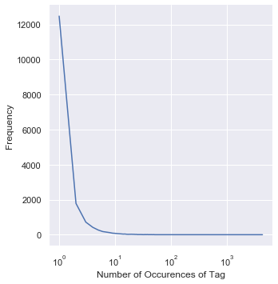

```python
tags.name = 'tags'
tag_frequencies = tags.explode().value_counts().value_counts().sort_index()
tags_df = tag_frequencies.to_frame().reset_index()

ax = seaborn.relplot(data = tags_df, x = 'index', y = 'tags', kind = 'line')
ax.set(xlabel = 'Number of Occurences of Tag', xscale = 'log', ylabel = 'Frequency')
```

```python
tags.explode().value_counts()
```

```
infection                                     4321
infections                                    1517
infectious diseases                           1069
respiratory syndrome                          1013
pneumonia                                      908
                                              ...
organomegaly                                     1
demyelinating canine distemper virus (cdv)       1
nuclease-sensitive                               1
fiv disease                                      1
funduscopy                                       1
Name: tags, Length: 17087, dtype: int64
```

```python
tag_counts = tags.explode().value_counts()
quantiles = [0.5, 0.75, 0.85, 0.95, 0.99]
min_count = np.quantile(tag_counts, q = quantiles)
print("Tag Frequency Quantiles")
pd.DataFrame([min_count], index = ['Tag Count'], columns = quantiles)
```

```
Tag Frequency Quantiles
```

|  | 0.50 | 0.75 | 0.85 | 0.95 | 0.99 |
| --- | --- | --- | --- | --- | --- |
| Tag Count | 1.0 | 2.0 | 3.0 | 10.0 | 51.14 |

```python
MIN_DOC_FREQ = 10
MIN_SUPPORT = MIN_DOC_FREQ/tags.explode().nunique()
print('Min Support: ', MIN_SUPPORT)
```

```
Min Support:  0.0005852402411189794
```

Arbitrarily, I will start with a min confidence of 0.25, and I will adjust this depending on the quality and quantity of rules discovered. This confidence fulfils the criteria that the lift of any generated rule is greater than 1, showing positive correllation between antecedent and consequent itemsets:

1. $ supp(X) = \dfrac{|X\subset{T}|}{|T|} $
2. $ \max_x{supp(X)} = \dfrac{\max_x{|X|}}{|T|} = \dfrac{1069}{23975} = 0.044 $
3. $ conf(X => Y) = \dfrac{supp(X \cup Y)}{supp(X)} $
4. $ lift(X => Y) = \dfrac{supp(X \cup Y)}{supp(X) \times supp(Y)} = \dfrac{conf(X => Y)}{supp(Y)}$
5. $ min_{x,y} lift(X => Y) = \dfrac{min_{x,y}conf(X => Y)}{max_y{supp(Y)}} = \dfrac{0.25}{0.044} > 1 $

### FP-Growth

```python
#disclude too-common terms and terms that already do not meat minimum threshold
allowed_tags = tag_counts[(tag_counts <= 1069) & (tag_counts >= MIN_DOC_FREQ)].index
allowed_tags
```

```
Index(['infectious diseases', 'respiratory syndrome', 'pneumonia',
       'acute respiratory syndrome', 'diarrhea', 'death', 'viral infection',
       'viral infections', 'severe acute respiratory syndrome', 'fever',
       ...
       'bursal disease virus', 'human immunodeficiency virus-1', 'burns',
       'effusions', 'lupus erythematosus', 'congenital heart disease',
       'immune-mediated disease', 'parvoviridae', 'urinary tract infections',
       'ovarian tumor'],
      dtype='object', length=871)
```

```python
exploded = tags.explode()
filtered_tags = exploded[exploded.isin(allowed_tags)].groupby(level = 0).apply(list)
```

```python
from mlxtend.preprocessing import TransactionEncoder
from mlxtend.frequent_patterns import fpgrowth
from mlxtend.frequent_patterns import association_rules
```

```python
encoder = TransactionEncoder()
itemsets = filtered_tags.values
encoded_itemsets = encoder.fit(itemsets).transform(itemsets)
fp_df = pd.DataFrame(encoded_itemsets, columns = encoder.columns_)
```

```python
freq_itemsets = fpgrowth(fp_df, min_support = MIN_SUPPORT, use_colnames = True)
```

### Analyze Association Rules

```python
pair_rules = pd.read_csv(os.path.join(data_dir, 'analysis_v2','pair_rules.csv'))
pair_rules = pair_rules.rename(columns = {'Unnamed: 0' : 'index'}).set_index('index')
```

```python
a_rules = association_rules(freq_itemsets, metric = 'confidence', min_threshold=0.25)
pair_rules = a_rules[(a_rules.antecedents.str.len() == 1) & (a_rules.consequents.str.len() == 1)]
pair_rules = pair_rules.iloc[:,0:7].sort_values('lift', ascending = True)
pair_rules['is_interesting'] = 'N'

def get_rule_string(row):
    return list(row.antecedents)[0] + ' -> ' + list(row.consequents)[0]

pair_rules['rule'] = pair_rules.apply(lambda x : get_rule_string(x), axis = 1)

def is_plurality_rule(rule):
    ant, cons = rule.split(' -> ')
    return not ant + 's' == cons and not cons + 's' == ant

pair_rules = pair_rules.loc[pair_rules['rule'].apply(lambda x : is_plurality_rule(x))]

pair_rules['support_direction'] = (pair_rules['antecedent support'] > pair_rules['consequent support'])\
    .astype(np.str)
```

```python
import plotly
import plotly.express as px
import plotly.graph_objects as go
```

```python
px.scatter(pair_rules,
           x = 'support', y = 'lift', hover_data = ['rule'], color = 'support_direction')
```

[interactive chart not shown]

By examining the plot above, I was able to construct a disease taxonomy for the corpus by drawing edges between nodes as prescribed association rules. The nodes are colored by whether the antecedent has more support (red) or the consequent (blue). I found that generally, a rule is drawn between two disease concepts that are related in the taxonomy, and the edge points from higher to lower support. Using this, I automatically generated the taxonomy, then hand-edited to ensure correctness using my biomedical background.

```python
def cycle(*edges):
    return list(permutations(edges, 2))
```

```python
pair_rules[['antecedent','consequent']] = pair_rules['rule'].str.split(' -> ', expand = True)
pair_rules = pair_rules.drop(columns = ['antecedents','consequents','is_interesting'])
```

```python
def generate_tax(row):
    return (row.antecedent, row.consequent, False) if row.support_direction else (row.consequent, row.antecedent, False)
tax_graph = pair_rules.apply(lambda x : generate_tax(x), axis = 1).apply(pd.Series)\
    .rename(columns = {0 : 'src', 1 : 'dest', 2 : 'cycle'})
```

```python
tax_graph.to_csv('./prelim_tax_graph.csv', index = False)
```

I combed through the taxonomy generated above and corrected the direction of relationships, drew two-way connections between terms that represent the same subject (COVID-19 & SARS-COV-2) when this wasn't automatically recognized, and eliminated redundant rules. Overall, I was pleased with the "automaticness" of this approach, as I curated less than 5% of the generated relationships.

```python
tax_graph = pd.read_csv('prelim_tax_graph.csv')

tax_graph = tax_graph[tax_graph.include == 'Y']
tax_graph = tax_graph[['src', 'dest']].where(tax_graph.Flip != 'Y', tax_graph[['dest','src']].values)
tax_graph = tax_graph.drop_duplicates()
taxonomy = nx.from_pandas_edgelist(tax_graph, 'src','dest')
#remove a lot of plurality issues. Next time, use the POS-parsing to singularize plural entities.
remove_nodes = [
    'respiratory tract infection',
    'lower respiratory tract infection',
    'acute respiratory infection',
    'respiratory infection',
    'respiratory illness',
    'acute respiratory illness',
    'hand, foot and mouth disease',
    'cancers',
    'tumors',
    'mers-cov infections',
    'astroviruses',
    'respiratory virus infections',
    'respiratory virual infection',
    'viral infections',
    'viral infection',
    'ari',
    'acute respiratory illness',
    'respiratory infections',
    'respiratory infections',
    'respiratory infections',
    'acute respiratory infections',
]

#add edges to pull in smaller components to the overall taxonomy
add_edges = [
    ('infectious disease outbreak', 'hiv/aids'),
    ('infectious disease outbreak', 'cholera'),
    *cycle('acute respiratory infections','acute respiratory tract infections'),
    *cycle('mers','mers-cov infection','middle east respiratory syndrome'),
    ('coronavirus disease','respiratory coronavirus'),
    ('sars','sars infection'),
    ('coronavirus disease','sars'),
    ('coronavirus (2019-ncov)','severe acute respiratory syndrome'),
    ('respiratory coronavirus', 'influenza b'),
    ('repsiratory coronavirus','sars-cov-2 infection'),
    ('repsiratory coronavirus','sars'),
    ('repsiratory coronavirus','mers'),
    *cycle('lrti','lower respiratory tract infections'),
    *cycle('sars','severe acute respiratory syndrome','sars-cov infection', 'sars infection'),
    *cycle('covid-19','sars-cov-2 infection','coronavirus disease 2019', 'coronavirus (2019-ncov)')
]
taxonomy.remove_nodes_from(remove_nodes)
taxonomy.add_edges_from(add_edges)

#this was the extent of hand-editing of the taxonomy.
#In the future, some of this could be automated with a closer attention to plurality issues and
#linking words that relate to the same concept. Word embeddings could be useful for that task
```

[output not shown]

```python
comms = list(nx.algorithms.community.label_propagation.asyn_lpa_communities(taxonomy))

def get_comm_label(node_name):
    for i, comm in enumerate(comms):
        if node_name in comm:
            return i
    return len(comms)

comm_labels = [
    get_comm_label(node)
    for node in taxonomy.nodes
]
```

```python
pos = nx.drawing.layout.spring_layout(taxonomy, k = 0.14)

node_names, node_pos = list(pos.keys()), np.array([list(x) for x in pos.values()])

graph_data = pd.DataFrame({'node' : node_names, 'community' : comm_labels,
        'x' : node_pos[:,0], 'y' : node_pos[:,1]})

color_scheme = pd.Series(px.colors.qualitative.Light24)
color_scheme.name = 'color'
color_scheme = color_scheme.to_frame().reset_index().rename(columns = {'index' : 'color_code'})

graph_data['color_code'] = graph_data['community'] % len(color_scheme)

graph_data = graph_data.merge(color_scheme, on = 'color_code')

edge_x = []
edge_y = []
for (src, dest) in taxonomy.edges():
    x0, y0 = pos[src]
    x1, y1 = pos[dest]
    edge_x.append(x0)
    edge_x.append(x1)
    edge_x.append(None)
    edge_y.append(y0)
    edge_y.append(y1)
    edge_y.append(None)

edge_trace = go.Scatter(
    x=edge_x, y=edge_y,
    line=dict(width=0.5, color='#888'),
    hoverinfo='none',
    mode='lines')

node_trace = go.Scatter(
    x = graph_data.x,
    y = graph_data.y,
    text = graph_data.node,
    mode = 'markers',
    marker_color = graph_data.color
)
fig = go.Figure()
fig.update_layout(
    showlegend = False,
    plot_bgcolor = '#1F2132',
    xaxis = dict(
        showticklabels = False,
        title = '',
        ),
    yaxis = dict(
        showticklabels = False,
        title = '',
        ),
    margin=dict(l=0,r=0,b=0,t=0,pad=4),
)
fig.add_trace(edge_trace)
fig.add_trace(node_trace)
```

[interactive chart not shown]

### Taxonomy

Finally, I've arrived at my taxonomy, represented above using a spring layout projection algorithm and with term communities colored according to the label propagation algorithm. I curated the graph again to connect obviously-related terms that the algorithm either missed or I prematurely pruned. I also eliminated redundant terms and plurality replicates. This automatic taxonomy construction technique proved to be more powerful than I initially expected, and created a coherent concept taxonomy purely unsupervised from the corpus. Post a little human editting, I am extremely pleased with the quality of the taxonomy.

This representation of key disease concepts will be used as the filtering device for Constellation. When a user selects a term from the taxonomy, articles will be filtered according to their containing that term, or any subordinate term.

### Saving Results

```python
graph_data.to_csv('./graph_data.csv')

with open('edge_data.json', 'w') as f:
    f.write(json.dumps(list(taxonomy.edges),indent = 4))
```

```python
tags = pd.read_csv(os.path.join(data_dir, 'analysis_v2', 'disease_tags.csv'))
tags.name = 'disease_tags'
tags = tags.groupby('index').agg(list)
tags['tags'] = tags.iloc[:,0].apply(lambda x : '|'.join([str(s) for s in x]))

data = data.join(tags['tags'], how = 'left')

data.reset_index().to_csv(os.path.join(data_dir, 'analysis_v2', 'metadata_plus_analysis.csv'), index = False)
```